# Reproducible Research Peer Assessment 1

## Loading and preprocessing the data

```r
Activity <- data.frame(read.csv("activity.csv"))

Activity$date <- as.Date(Activity$date,"%Y-%m-%d")
```

## What is the mean total number of steps taken per day?

### 1. Calculate the total number of steps taken per day

```r
StepsPerDay <- aggregate(steps ~ date, Activity, sum)
```

### 2. Make a histogram of the total number of steps taken each day

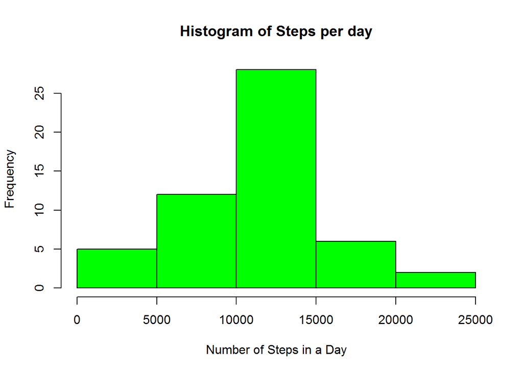

```r
hist(StepsPerDay$steps, main = "Histogram of Steps per day", xlab = "Number of Steps in a Day", col = "green")
```

### 3. Calculate and report the mean and median of the total number of steps taken per day

```r
mean(StepsPerDay$steps)
```

```
## [1] 10766.19
```

```r
median(StepsPerDay$steps)
```

```
## [1] 10765
```

## What is the average daily activity pattern?

### 1. Make a time series plot of the 5-minute interval (x-axis) and the average number of steps taken, averaged across all the days (y-axis)

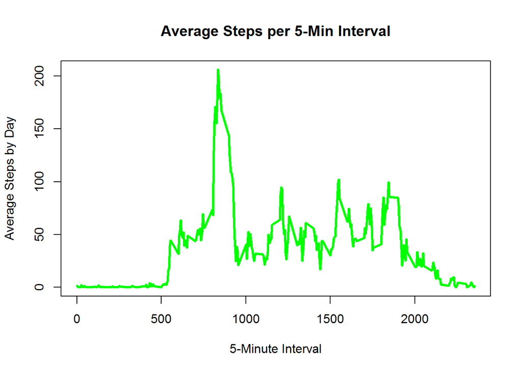

```r
AvStepsInterval <- aggregate(steps ~ interval, data = Activity, mean)

plot(AvStepsInterval$interval, AvStepsInterval$steps, type = "l", main = "Average Steps per 5-Min Interval", xlab = "5-Minute Interval", ylab = "Average Steps by Day", lwd = 3, col = "green")
```

### 2. Which 5-minute interval, on average across all the days in the dataset, contains the maximum number of steps?

```r
AvStepsInterval[which.max(AvStepsInterval$steps),]
```

```
##     interval    steps
## 104      835 206.1698
```

## Imputing missing values

### 1. Calculate and report the total number of missing values in the dataset

```r
sum(is.na(Activity$steps))
```

```
## [1] 2304
```

### 2. Devise a stratefy for filing in the missing values in the dataset.

I will use average for that 5-Minute Interval, averaged across all days

### 3. Create a new dataset that is equal to the original but with the missing data filled in

Prepare a new data frame and backup the original steps values

```r
require(plyr)
require(Hmisc)
ImputedActivity <- ddply(Activity, "interval", mutate, imputed.value = impute(steps,mean))
```

### 4. Make a higram of total number of steps taken each day and Calculate and report Mean and Median. What’s the impact of imputing mssing data?

```r
ImputedStepsPerDay <- aggregate(imputed.value ~ date, ImputedActivity, sum)
```

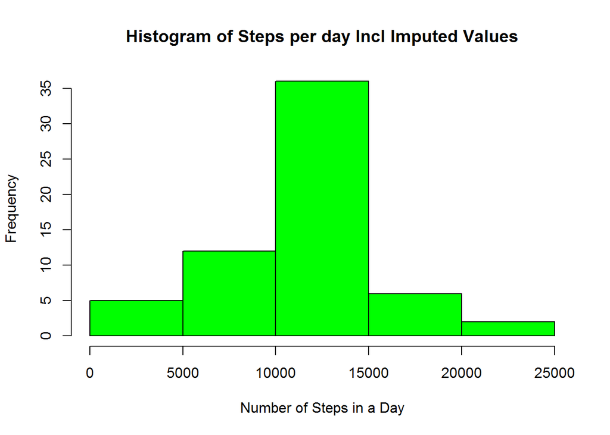

```r
hist(ImputedStepsPerDay$imputed.value, main = "Histogram of Steps per day Incl Imputed Values", xlab = "Number of Steps in a Day", col = "green")
```

Imputing missing values doesn’t appear to have had a huge impact on the histogram, clearly the middle point has more frequency

```r
mean(ImputedStepsPerDay$imputed.value)
```

```
## [1] 10766.19
```

```r
median(ImputedStepsPerDay$imputed.value)
```

```
## [1] 10766.19
```

Raise the Median steps per day to be in line with the mean, maybe it’s to be expected with using the mean for the imputing but not sure I’ve done this right…

## Are there differences in activity patterns between weekdays and weekends?

### 1. Create a new factor variable in the dataset with two levels - “weekday” and “weekend” indicating whether a given date is a weekday or weekend day.

```r
ImputedActivity$weekday <- as.factor(plyr::mapvalues(weekdays(ImputedActivity$date), from = c("Monday","Tuesday","Wednesday","Thursday","Friday","Saturday","Sunday"), to = c("Weekday","Weekday","Weekday","Weekday","Weekday","Weekend","Weekend")))
```

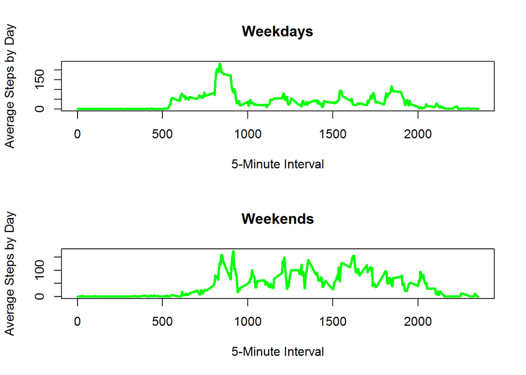

```r
par(mfrow= c(2,1))

WeekdayAvStepsInterval <- aggregate(steps ~ interval, data = ImputedActivity[ImputedActivity$weekday == "Weekday",], mean)

plot(WeekdayAvStepsInterval$interval, WeekdayAvStepsInterval$steps, type = "l", main = "Weekdays", xlab = "5-Minute Interval", ylab = "Average Steps by Day", lwd = 3, col = "green")

WeekendAvStepsInterval <- aggregate(steps ~ interval, data = ImputedActivity[ImputedActivity$weekday == "Weekend",], mean)

plot(WeekendAvStepsInterval$interval, WeekendAvStepsInterval$steps, type = "l", main = "Weekends", xlab = "5-Minute Interval", ylab = "Average Steps by Day", lwd = 3, col = "green")
```